# Validation

Brian M. Schilder

2023-12-21

**Tools** - [scOntoMatch](https://github.com/Papatheodorou-Group/scOntoMatch/) - metacells - SATURN

**Datasets** - [HumanCellLandscape](https://cellxgene.cziscience.com/collections/38833785-fac5-48fd-944a-0f62a4c23ed1) - [DescartesHuman](https://cellxgene.cziscience.com/collections/c114c20f-1ef4-49a5-9c2e-d965787fb90c) - [1 million-cell subset](https://cellxgene.cziscience.com/collections/c114c20f-1ef4-49a5-9c2e-d965787fb90c)

```r
library(MSTExplorer)
```

```r
library(ggplot2)
```

# Import data

## MSTExplorer results

```r
ctd_names <- c("DescartesHuman","HumanCellLandscape")
res <- lapply(stats::setNames(ctd_names,ctd_names), function(x){
  readRDS(paste0("/Volumes/bms20/projects/neurogenomics-lab/live/Projects/rare_disease_ewce/pbs/",x,"/rare_disease_min_genes4.rds"))
})
```

## scRNAseq

```r
obj_list <- list()
obj_list[["DescartesHuman"]] <- readRDS("~/Downloads/db4d63ab-0ca3-4fa5-b0cf-34955227912d.rds")
obj_list[["HumanCellLandscape"]] <- readRDS("~/Downloads/1b7484e3-83a0-47fe-847e-54d811a2adae.rds")
```

## Map CellOntology IDs onto original names in results files

```r
map_celltypes <- function(dat,
                          map,
                          celltype_col = list(
                            dat="CellType",
                            map=c("Main_cluster_name",
                                  "author_cell_type")
                          ),
                          cellontology_id_col=list(
                            map=c("cell_type_ontology_term_id",
                                  "cell_type")
                          ),
                          rm_prefixes=c("Adult","Fetus","HESC")
                          ){
  #### Ensure both inputs are data.tables ####
  map <- data.table::as.data.table(map)
  celltype_col$map <- celltype_col$map[
    celltype_col$map %in% names(map)
  ]
  cellontology_id_col$map <- cellontology_id_col$map[
    cellontology_id_col$map %in% names(map)
  ]
  map <- map[,c(celltype_col$map, cellontology_id_col$map), with=FALSE] |>
    unique()
  map <- map[,.SD[1], by=c(celltype_col$map)]
  dat <- data.table::as.data.table(dat)
  #### Map original cell annotation to EWCE standardised version ####
  map[,(celltype_col$dat):=EWCE::fix_celltype_names(get(celltype_col$map),
                                                    make_unique = FALSE)]
  if(!is.null(rm_prefixes)){
    dat[,(celltype_col$dat):=gsub(
      pattern=paste0(paste0("^",rm_prefixes,"_"),collapse="|"),
      replacement="",
      x=get(celltype_col$dat), ignore.case = TRUE)]
  }
  #### Merge ####
  dat_mapped <- data.table::merge.data.table(x = dat,
                                             y = map,
                                             by = celltype_col$dat,
                                             all.x = TRUE,
                                             all.y = FALSE)
  data.table::setnames(dat_mapped,
                       c(celltype_col$map,"cell_type"),
                       c("CellType_original","cell_type_ontology"),
                       skip_absent = TRUE)
  return(dat_mapped)
}

res_mapped <- lapply(stats::setNames(names(res),
                                     names(res)),
                     function(x){
  dat <- res[[x]]
   if(x=="DescartesHuman"){
    dat[,stage:="Fetus"]
  }
  if(x=="HumanCellLandscape"){
    dat[,stage:=data.table::tstrsplit(CellType,"_",keep=1)]
  }
  map_celltypes(dat = dat,
                map = obj_list[[x]]@meta.data)
})
```

### Merge all results

Merge all results into a single data.table.

```r
RES <- data.table::rbindlist(res_mapped, idcol = "ctd")
RES[,pheno_celltype:=paste(hpo_id,cell_type_ontology_term_id,sep="_")]
### Count number of unique celltypes per CTD/stage ###
RES[,list(N=length(unique(CellType))), by=c("ctd","stage")]
```

```
##                   ctd stage  N
## 1:     DescartesHuman Fetus 77
## 2: HumanCellLandscape Fetus 58
## 3: HumanCellLandscape Adult 61
## 4: HumanCellLandscape  HESC  5
```

## CellTypeDatasets

```r
ctd <- lapply(stats::setNames(ctd_names,ctd_names), function(x){
  MSTExplorer::load_example_ctd(paste0("ctd_",x,".rds"))
})
Xctd <- lapply(ctd_names, function(x){
  lvl <- ctd_lvls["DescartesHuman"][[2]]
  ctd[[x]][[lvl]]$specificity
}) |> do.call(what = Seurat::RowMergeSparseMatrices)
```

## Harmonise celltypes

Only 13 celltype IDs are shared between the two datasets, partly due to differing ontology level annotations.

```r
report_matches <- function(obj_list,
                           col="cell_type"){
  lapply(obj_list, function(x){
    ct <- unique(x@meta.data[[col]])
    message(col,": ",length(ct))
    return(ct)
  }) |> Reduce(f=intersect)
}
report_matches(obj_list, col="cell_type")
```

```
## cell_type: 72
```

```
## cell_type: 44
```

```
##  [1] "stromal cell"
##  [2] "astrocyte"
##  [3] "smooth muscle cell"
##  [4] "cell of skeletal muscle"
##  [5] "myeloid cell"
##  [6] "oligodendrocyte"
##  [7] "neuron"
##  [8] "ventricular cardiac muscle cell"
##  [9] "mesothelial cell"
## [10] "acinar cell"
## [11] "endocrine cell"
## [12] "goblet cell"
## [13] "professional antigen presenting cell"
```

Thus, we must traverse the ontology to find the last common ancestor of each cell type. We use `scOntoMatch` to do this.

```r
ont <- ontologyIndex::get_OBO(
  file = "https://github.com/obophenotype/cell-ontology/releases/download/v2023-10-19/cl-basic.obo")

# obj_list_minimal = scOntoMatch::ontoMultiMinimal(obj_list = obj_list,
#                                                  ont = ont,
#                                                  anno_col = "cell_type",
#                                                  onto_id_col = "cell_type_ontology_term_id")
# report_matches(obj_list, col="cell_ontology_base")

obj_list$DescartesHuman$CellType <- EWCE::fix_celltype_names(obj_list$DescartesHuman$Main_cluster_name, make_unique = FALSE)
```

[output not shown]

```r
obj_list$HumanCellLandscape$CellType <- EWCE::fix_celltype_names(obj_list$HumanCellLandscape$author_cell_type,
                                                                 make_unique = FALSE)

obj_list_matched <- scOntoMatch::ontoMultiMatch(
  obj_list = obj_list,
  ont = ont,
  anno_col = 'cell_type',
  onto_id_col = "cell_type_ontology_term_id")
```

```
## use existing ontology id
```

[output not shown]

```
## processing DescartesHuman
```

```
## mapping from name: mesothelial cell to name: mesothelial cell
```

```
## mapping from name: astrocyte to name: astrocyte
```

```
## mapping from name: oligodendrocyte to name: oligodendrocyte
```

```
## mapping from name: professional antigen presenting cell to name: professional antigen presenting cell
```

```
## mapping from name: goblet cell to name: goblet cell
```

```
## mapping from name: endocrine cell to name: endocrine cell
```

```
## mapping from name: cell of skeletal muscle to name: cell of skeletal muscle
```

```
## mapping from name: smooth muscle cell to name: smooth muscle cell
```

```
## mapping from name: stromal cell to name: stromal cell
```

```
## mapping from name: neuron to name: neuron
```

```
## mapping from name: acinar cell to name: acinar cell
```

```
## mapping from name: myeloid cell to name: myeloid cell
```

```
## mapping from name: ventricular cardiac muscle cell to name: ventricular cardiac muscle cell
```

```
## mapping from name: cord blood hematopoietic stem cell to name: hematopoietic cell
```

```
## mapping from name: enterocyte to name: epithelial cell
```

```
## mapping from name: epithelial cell of proximal tubule to name: epithelial cell
```

```
## mapping from name: blood vessel endothelial cell to name: endothelial cell
```

```
## mapping from name: corneal epithelial cell to name: epithelial cell
```

```
## mapping from name: Sertoli cell to name: epithelial cell
```

```
## mapping from name: macroglial cell to name: glial cell
```

```
## mapping from name: microglial cell to name: macrophage
```

```
## mapping from name: Mueller cell to name: glial cell
```

```
## mapping from name: Schwann cell to name: glial cell
```

```
## mapping from name: chromaffin cell to name: epithelial cell
```

```
## mapping from name: regular atrial cardiac myocyte to name: cardiac muscle cell
```

```
## mapping from name: hematopoietic stem cell to name: hematopoietic cell
```

```
## mapping from name: megakaryocyte to name: hematopoietic cell
```

```
## mapping from name: erythroblast to name: erythroid lineage cell
```

```
## mapping from name: thymocyte to name: T cell
```

```
## mapping from name: innate lymphoid cell to name: hematopoietic cell
```

```
## mapping from name: erythroid progenitor cell to name: erythroid lineage cell
```

```
## mapping from name: T cell to name: hematopoietic cell
```

```
## mapping from name: mast cell to name: hematopoietic cell
```

```
## mapping from name: macrophage to name: hematopoietic cell
```

```
## mapping from name: B cell to name: hematopoietic cell
```

```
## mapping from name: dendritic cell to name: hematopoietic cell
```

```
## mapping from name: monocyte to name: hematopoietic cell
```

```
## mapping from name: erythroid lineage cell to name: hematopoietic cell
```

```
## mapping from name: neutrophil to name: hematopoietic cell
```

```
## mapping from name: plasma cell to name: hematopoietic cell
```

```
## mapping from name: alternatively activated macrophage to name: macrophage
```

```
## mapping from name: dermis microvascular lymphatic vessel endothelial cell to name: endothelial cell
```

```
## mapping from name: endothelial cell of lymphatic vessel to name: endothelial cell
```

```
## mapping from name: hepatic stellate cell to name: fibroblast
```

```
## mapping from name: ciliated epithelial cell to name: epithelial cell
```

```
## mapping from name: squamous epithelial cell to name: epithelial cell
```

```
## mapping from name: neuroendocrine cell to name: epithelial cell
```

```
## mapping from name: taste receptor cell to name: epithelial cell
```

```
## mapping from name: pancreatic ductal cell to name: epithelial cell of exocrine pancreas
```

```
## mapping from name: cortical cell of adrenal gland to name: epithelial cell
```

```
## mapping from name: endothelial cell of vascular tree to name: endothelial cell
```

```
## mapping from name: brush cell to name: epithelial cell
```

```
## mapping from name: epithelial cell of thymus to name: epithelial cell
```

```
## mapping from name: endocardial cell to name: endothelial cell
```

```
## mapping from name: intestinal epithelial cell to name: epithelial cell
```

```
## mapping from name: retinal pigment epithelial cell to name: epithelial cell
```

```
## mapping from name: epithelial cell of lower respiratory tract to name: epithelial cell
```

```
## mapping from name: lens fiber cell to name: epithelial cell
```

```
## mapping from name: stratified epithelial cell to name: epithelial cell
```

```
## mapping from name: endothelial cell to name: epithelial cell
```

```
## mapping from name: peptic cell to name: epithelial cell
```

```
## mapping from name: type II pneumocyte to name: epithelial cell
```

```
## mapping from name: thyroid follicular cell to name: epithelial cell
```

```
## mapping from name: renal intercalated cell to name: epithelial cell
```

```
## mapping from name: kidney loop of Henle epithelial cell to name: epithelial cell
```

```
## mapping from name: epithelial cell of exocrine pancreas to name: epithelial cell
```

```
## after matching across datasets, DescartesHuman has cell types:
```

```
## acinar cell, amacrine cell, astrocyte, bipolar neuron, cardiac muscle cell, cell of skeletal muscle, chorionic trophoblast cell, endocrine cell, endothelial cell, enteric neuron, epicardial adipocyte, epithelial cell, epithelial cell of exocrine pancreas, erythroid lineage cell, extravillous trop…
```

```
## processing HumanCellLandscape
```

```
## mapping from name: mesothelial cell to name: mesothelial cell
```

```
## mapping from name: astrocyte to name: astrocyte
```

```
## mapping from name: oligodendrocyte to name: oligodendrocyte
```

```
## mapping from name: professional antigen presenting cell to name: professional antigen presenting cell
```

```
## mapping from name: goblet cell to name: goblet cell
```

```
## mapping from name: endocrine cell to name: endocrine cell
```

```
## mapping from name: cell of skeletal muscle to name: cell of skeletal muscle
```

```
## mapping from name: smooth muscle cell to name: smooth muscle cell
```

```
## mapping from name: stromal cell to name: stromal cell
```

```
## mapping from name: neuron to name: neuron
```

```
## mapping from name: acinar cell to name: acinar cell
```

```
## mapping from name: myeloid cell to name: myeloid cell
```

```
## mapping from name: ventricular cardiac muscle cell to name: ventricular cardiac muscle cell
```

```
## mapping from name: cord blood hematopoietic stem cell to name: hematopoietic cell
```

```
## mapping from name: enterocyte to name: epithelial cell
```

```
## mapping from name: epithelial cell of proximal tubule to name: epithelial cell
```

```
## mapping from name: blood vessel endothelial cell to name: endothelial cell
```

```
## mapping from name: corneal epithelial cell to name: epithelial cell
```

```
## mapping from name: Sertoli cell to name: epithelial cell
```

```
## mapping from name: macroglial cell to name: glial cell
```

```
## mapping from name: microglial cell to name: macrophage
```

```
## mapping from name: Mueller cell to name: glial cell
```

```
## mapping from name: Schwann cell to name: glial cell
```

```
## mapping from name: chromaffin cell to name: epithelial cell
```

```
## mapping from name: regular atrial cardiac myocyte to name: cardiac muscle cell
```

```
## mapping from name: hematopoietic stem cell to name: hematopoietic cell
```

```
## mapping from name: megakaryocyte to name: hematopoietic cell
```

```
## mapping from name: erythroblast to name: erythroid lineage cell
```

```
## mapping from name: thymocyte to name: T cell
```

```
## mapping from name: innate lymphoid cell to name: hematopoietic cell
```

```
## mapping from name: erythroid progenitor cell to name: erythroid lineage cell
```

```
## mapping from name: T cell to name: hematopoietic cell
```

```
## mapping from name: mast cell to name: hematopoietic cell
```

```
## mapping from name: macrophage to name: hematopoietic cell
```

```
## mapping from name: B cell to name: hematopoietic cell
```

```
## mapping from name: dendritic cell to name: hematopoietic cell
```

```
## mapping from name: monocyte to name: hematopoietic cell
```

```
## mapping from name: erythroid lineage cell to name: hematopoietic cell
```

```
## mapping from name: neutrophil to name: hematopoietic cell
```

```
## mapping from name: plasma cell to name: hematopoietic cell
```

```
## mapping from name: alternatively activated macrophage to name: macrophage
```

```
## mapping from name: dermis microvascular lymphatic vessel endothelial cell to name: endothelial cell
```

```
## mapping from name: endothelial cell of lymphatic vessel to name: endothelial cell
```

```
## mapping from name: hepatic stellate cell to name: fibroblast
```

```
## mapping from name: ciliated epithelial cell to name: epithelial cell
```

```
## mapping from name: squamous epithelial cell to name: epithelial cell
```

```
## mapping from name: neuroendocrine cell to name: epithelial cell
```

```
## mapping from name: taste receptor cell to name: epithelial cell
```

```
## mapping from name: pancreatic ductal cell to name: epithelial cell of exocrine pancreas
```

```
## mapping from name: cortical cell of adrenal gland to name: epithelial cell
```

```
## mapping from name: endothelial cell of vascular tree to name: endothelial cell
```

```
## mapping from name: brush cell to name: epithelial cell
```

```
## mapping from name: epithelial cell of thymus to name: epithelial cell
```

```
## mapping from name: endocardial cell to name: endothelial cell
```

```
## mapping from name: intestinal epithelial cell to name: epithelial cell
```

```
## mapping from name: retinal pigment epithelial cell to name: epithelial cell
```

```
## mapping from name: epithelial cell of lower respiratory tract to name: epithelial cell
```

```
## mapping from name: lens fiber cell to name: epithelial cell
```

```
## mapping from name: stratified epithelial cell to name: epithelial cell
```

```
## mapping from name: endothelial cell to name: epithelial cell
```

```
## mapping from name: peptic cell to name: epithelial cell
```

```
## mapping from name: type II pneumocyte to name: epithelial cell
```

```
## mapping from name: thyroid follicular cell to name: epithelial cell
```

```
## mapping from name: renal intercalated cell to name: epithelial cell
```

```
## mapping from name: kidney loop of Henle epithelial cell to name: epithelial cell
```

```
## mapping from name: epithelial cell of exocrine pancreas to name: epithelial cell
```

```
## after matching across datasets, HumanCellLandscape has cell types:
```

```
## acinar cell, astrocyte, basal cell, cell of skeletal muscle, chondrocyte, embryonic stem cell, endocrine cell, epithelial cell, erythroid lineage cell, fibroblast, goblet cell, hematopoietic cell, inflammatory cell, macrophage, mesenchymal stem cell, mesothelial cell, myeloid cell, neuron, oligod…
```

```r
report_matches(obj_list_matched, col="cell_ontology_mapped")
```

```
## cell_ontology_mapped: 49
```

```
## cell_ontology_mapped: 24
```

```
##  [1] "stromal cell"
##  [2] "epithelial cell"
##  [3] "astrocyte"
##  [4] "macrophage"
##  [5] "smooth muscle cell"
##  [6] "cell of skeletal muscle"
##  [7] "erythroid lineage cell"
##  [8] "hematopoietic cell"
##  [9] "myeloid cell"
## [10] "oligodendrocyte"
## [11] "neuron"
## [12] "ventricular cardiac muscle cell"
## [13] "mesothelial cell"
## [14] "fibroblast"
## [15] "acinar cell"
## [16] "endocrine cell"
## [17] "goblet cell"
## [18] "professional antigen presenting cell"
```

```r
map <- lapply(obj_list_matched, function(x){
  x@meta.data |>
    dplyr::select(CellType,
                  # cell_type,
                  # cell_type_ontology_term_id,
                  cell_ontology_mapped) |>
    unique()
}) |>
  data.table::rbindlist(idcol = "ctd", fill = TRUE)
RES_MAPPED <- data.table::merge.data.table(
  RES,
  map,
  by= c("ctd","CellType"),
  allow.cartesian = TRUE
)
```

# Compare results

## Across datasets: DescartesHuman vs HumanCellLandscape

```r
RES2 <- RES_MAPPED|>
  # subset(stage=="Fetus") |>
  # subset(q<0.05)|>
  data.table::dcast.data.table(
  formula = hpo_id+stage+cell_ontology_mapped ~ ctd,
  fun.aggregate = mean,
  drop = TRUE,
  value.var = c("p","q","fold_change"))
RES2 <- RES2[complete.cases(RES2)][,test_id:=.I]
### All results
message(length(unique(RES2$cell_ontology_mapped))," comparable celltypes.")
```

```
## 16 comparable celltypes.
```

```r
message(length(unique(RES2$hpo_id))," comparable phenotypes.")
```

```
## 6000 comparable phenotypes.
```

```r
### Significant results in both CTDs
RES_SIG <- RES2[q_HumanCellLandscape<.05 & q_DescartesHuman<.05]
message(length(unique(RES_SIG$cell_ontology_mapped))," comparable celltypes (FDR<0.05).")
```

```
## 6 comparable celltypes (FDR<0.05).
```

```r
message(length(unique(RES_SIG$hpo_id))," comparable phenotypes (FDR<0.05).")
```

```
## 226 comparable phenotypes (FDR<0.05).
```

### All results (q<1)

This plot makes no distinction between stages in DescartesHumna (fetal only) and HumanCellLandscape (Human Embyronic Stem Cells (HESC), Fetal, and Adult).

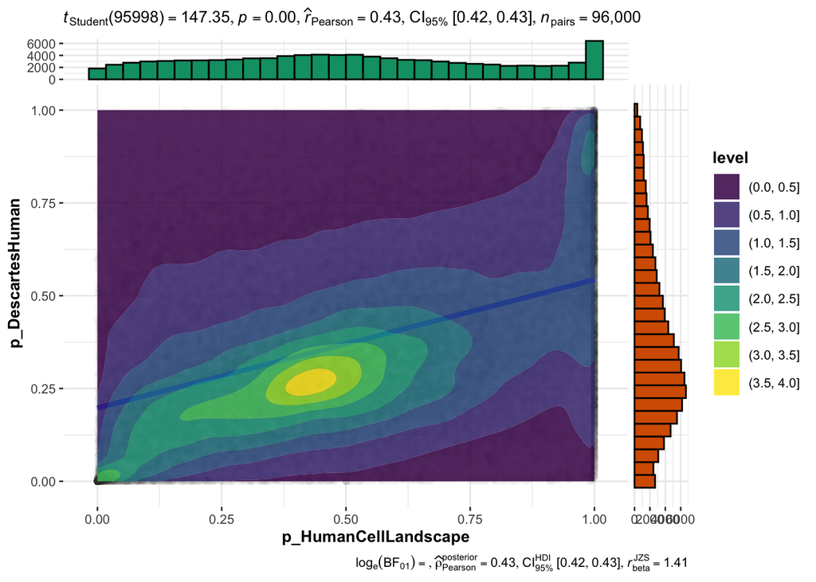

```r
RES2 |>
  ggstatsplot::ggscatterstats(x="p_HumanCellLandscape",
                              y="p_DescartesHuman",
                              point.args = list(alpha=.01)) +
    ggplot2::geom_density_2d_filled(alpha=.85)
```

### Signficant results (q<0.05)

```r
plot_cor <- function(dt,
                     x="fold_change_HumanCellLandscape",
                     y="fold_change_DescartesHuman",
                     trans='log10'){
gg <- dt |>
  # subset(stage=="Fetus")|>
  # subset(q_DescartesHuman<0.05 & q_HumanCellLandscape<0.05) |>
  ggplot(aes(x=!!sym(x),
                 y=!!sym(y)
  )) +
  geom_density_2d_filled() +
  geom_point(alpha=.2, color="white")+
  # geom_hex() +
  geom_smooth(method="lm") +
  ggpubr::stat_cor(color="white")+
  ggside::geom_xsidehistogram(fill="blue") +
  ggside::geom_ysidehistogram(fill="slateblue") +
  theme_bw()
  if(!is.null(trans)){
    gg <- gg +
      scale_x_continuous(trans=trans) +
      scale_y_continuous(trans=trans) +
      labs(x=paste0(trans,"(",x,")"),
           y=paste0(trans,"(",y,")"))
  }
  return(gg)
}
```

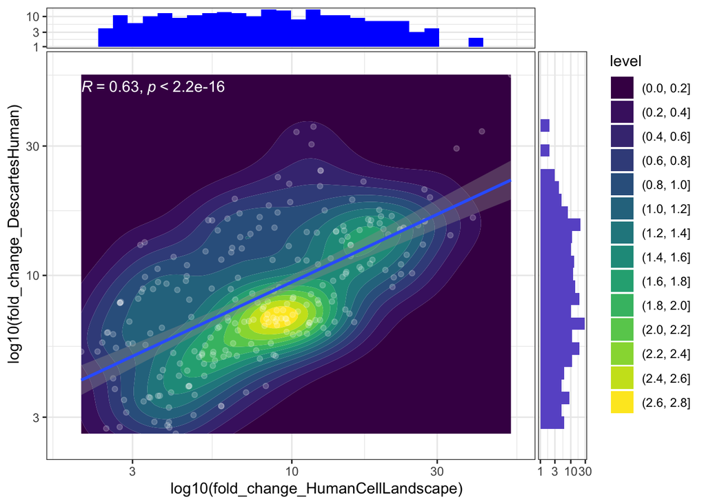

```r
plot_cor(RES_SIG,
         x="fold_change_HumanCellLandscape",
         y="fold_change_DescartesHuman")
```

### Precision-Recall

Compute the % of significant (FDR<5%) phenotype-celltype enrichment results recapitulated using each reference.

```r
compute_pr <- function(dt,
                       ref_qcut=.05){
  ground_truth <- dt[q_DescartesHuman<ref_qcut]$test_id
  lapply(c(0.001,0.01,seq(0,1,.05)), function(pcut){
    r2 <- dt[q_HumanCellLandscape<pcut]
    TP <- r2$test_id %in% ground_truth |> length()
    TN <- !(r2$test_id %in% ground_truth) |> length()
    FN <- ground_truth[!(ground_truth %in% r2$test_id)] |> length()
    FP <- r2$test_id[!(r2$test_id %in% ground_truth)] |> length()
    data.table::data.table(
      # TP/TP+FP
      precision=TP/(TP+FP),
      # TP/TP+FN
      recall=TP/(TP+FN),
      # TP+TN/total
      accuracy=(TP+TN)/(TP+TN+FP+FN),
      ## Add pvalue threshold
      pvalue_threshold=pcut,
      ref_qcut=ref_qcut
    )
}) |> data.table::rbindlist()
}
```

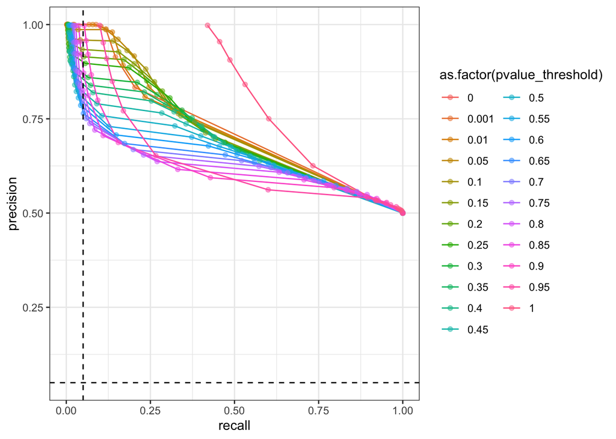

```r
pr <- lapply(c(0.01,0.05,seq(0,1,.1)), function(ref_qcut){
  compute_pr(RES2, ref_qcut=ref_qcut)
})|> data.table::rbindlist()

pr |>
  ggplot(aes(x=recall, y=precision,
             color=as.factor(pvalue_threshold))) +
  geom_line() +
  geom_point(alpha=.5) +
  geom_hline(yintercept=.05, linetype="dashed") +
  geom_vline(xintercept=.05, linetype="dashed") +
  theme_bw()
```

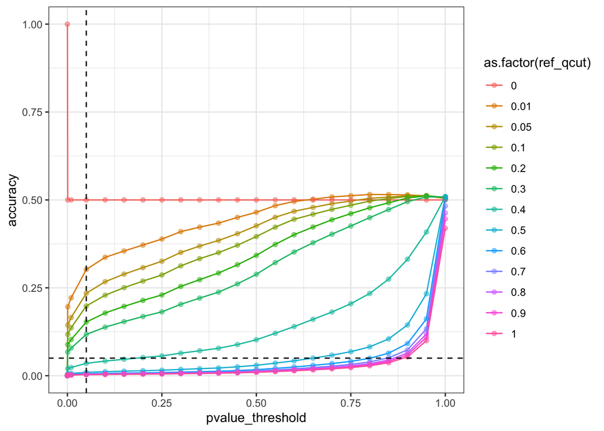

```r
## plot accuracy vs. pvalue threshold
pr |>
  ggplot(aes(x=pvalue_threshold, y=accuracy,
             color=as.factor(ref_qcut))) +
  geom_line() +
  geom_point(alpha=.5) +
  geom_hline(yintercept=.05, linetype="dashed") +
  geom_vline(xintercept=.05, linetype="dashed") +
  theme_bw()
```

## Within datasets: HumanCellLandscape

```r
RES_HCL <- RES_MAPPED[ctd=="HumanCellLandscape"] |>
  subset(stage!="HESC")|>
  data.table::dcast.data.table(
  formula = hpo_id+cell_ontology_mapped ~ stage,
  fun.aggregate = mean,
  drop = TRUE,
  value.var = c("p","q","fold_change"))
RES_HCL <- RES_HCL[complete.cases(RES_HCL)][,test_id:=.I]
### All results
message(length(unique(RES_HCL$cell_ontology_mapped))," comparable celltypes.")
```

```
## 21 comparable celltypes.
```

```r
message(length(unique(RES_HCL$hpo_id))," comparable phenotypes.")
```

```
## 6012 comparable phenotypes.
```

```r
### Significant results in both CTDs
RES_SIG <- RES_HCL[q_Adult<.05 & q_Fetus<.05]
message(length(unique(RES_SIG$cell_ontology_mapped))," comparable celltypes (FDR<0.05).")
```

```
## 6 comparable celltypes (FDR<0.05).
```

```r
message(length(unique(RES_SIG$hpo_id))," comparable phenotypes (FDR<0.05).")
```

```
## 149 comparable phenotypes (FDR<0.05).
```

## All results (q<1)

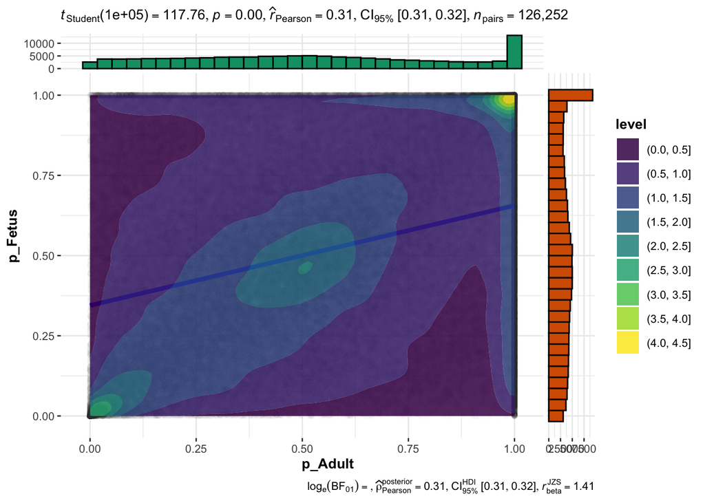

```r
RES_HCL |>
  ggstatsplot::ggscatterstats(x="p_Adult",
                              y="p_Fetus",
                              point.args = list(alpha=.01)) +
    ggplot2::geom_density_2d_filled(alpha=.85)
```

## Signficant results (q<0.05)

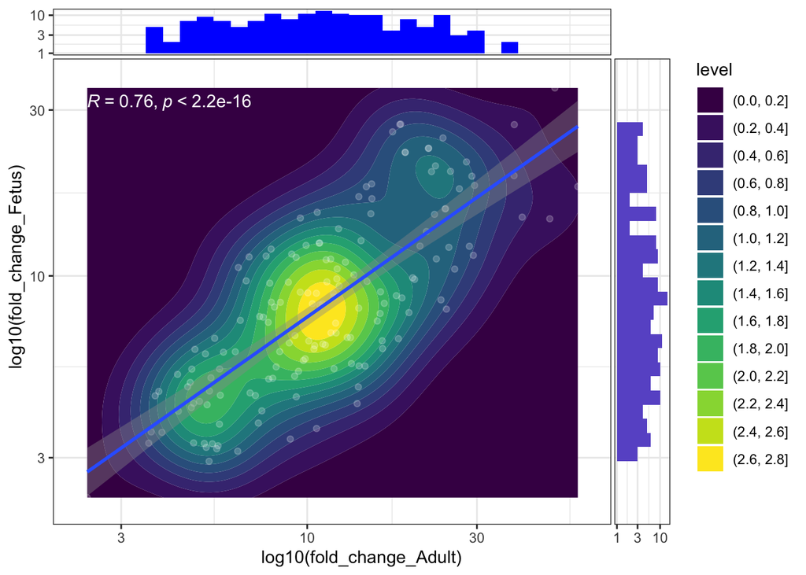

```r
plot_cor(RES_SIG,
         x="fold_change_Adult",
         y="fold_change_Fetus")
```

## Significant in only Adult OR Fetus

```r
adult_only <- RES_HCL[q_Adult<.05 & q_Fetus>=.05]
fetus_only <- RES_HCL[q_Adult>=.05 & q_Fetus<.05]
```

# Ground truth

Compare the results to some ground truth datasets from the Monarch Knowledge Graph.

## Manual inspection

After manual inspection it was found that 100% of known causal cell types (and/or their immediate precursors) were recapitulated by our MSTExplorer results. In many instances, our results further resolved the specific cell subtype(s) underlying the phenotype (e.g. “neuron” to “visceromotor neuron”, or “muscle cell” to “ventricular cardiac muscle cell”).

Sperm and other germ cells could not be assessed due to their absence in both transcriptomic reference datasets.

```r
RES <- data.table::rbindlist(res_mapped, idcol = "ctd")

kg <- data.table::fread("~/Downloads/monarch_kg_cells.csv")
kg <- kg[from %in% unique(RES$hpo_id)]
message(paste(
  "Remaining:",length(unique(kg$from)),
  "phenotypes across",length(unique(kg$to)),"celltypes."
))
```

```
## Remaining: 64 phenotypes across 52 celltypes.
```

```r
kg_res <- data.table::merge.data.table(
  kg[,c("from","to","label.to")],
  RES[q<0.05],
  by.x="from",
  by.y="hpo_id") |>
  data.table::setorderv(c("from","fold_change"), c(1,-1))

#### Compute average number of celltypes / phenotype ####
kg[,list(N=data.table::uniqueN(to)), by="from"]$N|>summary()
```

```
##    Min. 1st Qu.  Median    Mean 3rd Qu.    Max.
##       1       1       1       1       1       1
```

```r
kg_res[,list(N=data.table::uniqueN(CellType)), by="from"]$N|>summary()
```

```
##    Min. 1st Qu.  Median    Mean 3rd Qu.    Max.
##     1.0     2.0     4.0     7.5     9.0    37.0
```

## Traversing cell ontologies

```r
map_ontology_ids <- function(ont,
                             from_ids,
                             to_ids,
                             method=c( "getOntoMapping",
                                       "getOntoMultiMapping"
                                      )
                             ){
  from_name <- to_name <- NULL;

  method <- method[1]
  from_ids <- as.character(unique(from_ids))
  to_ids <- as.character(unique(to_ids))
  if(method=="getOntoMultiMapping"){
    mapped <- scOntoMatch::getOntoMultiMapping(
      ont = ont,
      onts = list(from_ids=from_ids,
                  to_ids=to_ids))
  } else {
     mapped <- scOntoMatch::getOntoMapping(ont = ont,
                                           onts1 = from_ids,
                                           onts2 = to_ids)
  }

  map <- data.table::data.table(from=names(mapped),
                                to=unname(mapped))
  map[,from_name:=scOntoMatch::getOntologyName(ont, from)[from]]
  map[,to_name:=scOntoMatch::getOntologyName(ont, to)[to]]
  return(map)
}
```

```r
compare_results <- function(obj_list,
                            RES,
                            datasets=NULL){

  kg <- data.table::fread("~/Downloads/monarch_kg_cells.csv")
  obj <- SeuratObject::pbmc_small[,seq(nrow(kg))]
  obj@meta.data <- kg[,cell_type:=label.to][,cell_type_ontology_term_id:=to]
  obj_list[["Monarch_KG"]] <- obj

  #### Subset datasets ####
  if(!is.null(datasets)){
    obj_list <- obj_list[datasets]
    RES <- RES[ctd %in% datasets]
  }
  #### Map ####
  obj_list_matched <- scOntoMatch::ontoMultiMatch(obj_list = obj_list,
                                                 ont = ont,
                                                 anno_col = 'cell_type',
                                                 onto_id_col = "cell_type_ontology_term_id")
  report_matches(obj_list_matched, col="cell_ontology_mapped")

  map <- lapply(obj_list_matched, function(x)x@meta.data) |>
    data.table::rbindlist(idcol = "dataset", fill=TRUE) |>
    dplyr::select(cell_type,cell_type_ontology_term_id,cell_ontology_mapped) |>
    unique()
  kg_mapped <- (
    data.table::merge.data.table(
      kg,
      map,
      by.x="to",
      by.y="cell_type_ontology_term_id")
  )[,cell_type_ontology_term_id:=to]
  kg_mapped[,pheno_celltype:=paste(from,cell_ontology_mapped,sep="_")]
  RES_MAPPED <- data.table::merge.data.table(
      RES,
      map,
      by.x="cell_type_ontology_term_id",
      by.y="cell_type_ontology_term_id")
  RES_MAPPED[,pheno_celltype:=paste(hpo_id,cell_ontology_mapped,sep="_")]
  pc_intersect <- intersect(unique(kg_mapped[cell_ontology_mapped!="cell"]$pheno_celltype),
                            unique(RES_MAPPED$pheno_celltype))
  kg_mapped <- kg_mapped[pheno_celltype %in% pc_intersect]
  RES_MAPPED <- RES_MAPPED[pheno_celltype %in% pc_intersect]
  #### What proportion of the Monarch KG is covered by the MSTExplorer results? ####
  RES_MAPPED[pheno_celltype %in% kg_mapped$pheno_celltype][,list(
    TP=sum(unique(pheno_celltype) %in% unique(kg_mapped$pheno_celltype)),
    n_res_kg=length(unique(kg_mapped$pheno_celltype)),
    n_res=length(unique(pheno_celltype)),
    n_res_sig=length(unique(pheno_celltype[q<.05])),
    n_res_sig_p=length(unique(pheno_celltype[p<.05]))
    ), by=c("ctd","stage")]
}



reports <- lapply(stats::setNames(ctd_names,ctd_names), function(x){
  compare_results(obj_list,
                  RES,
                  datasets=x)
})

compare_results(obj_list,
                RES)
```

[output not shown]